# tarea3_guevaragabriel

```
RESULTADO_1A = 25
RESULTADO_1B = 2025-01-16
RESULTADO_1C = 25
RESULTADO_2A = 0.0032
RESULTADO_2B = Garabito
RESULTADO_2C = 1
RESULTADO_2D = Hojancha
RESULTADO_3A = 21765923831.82
RESULTADO_3B = 853206531.82
RESULTADO_3C = 21484427109.34
```

## Ejercicio 1 — Alertas por ventana móvil

Se analizaron las transacciones diarias de 2025 utilizando una ventana de 7 días y un factor de 2 desviaciones estándar.

Se identificaron **25 días con alerta**, siendo el primero el **16 de enero de 2025**.

### Gráfico de transacciones y alertas

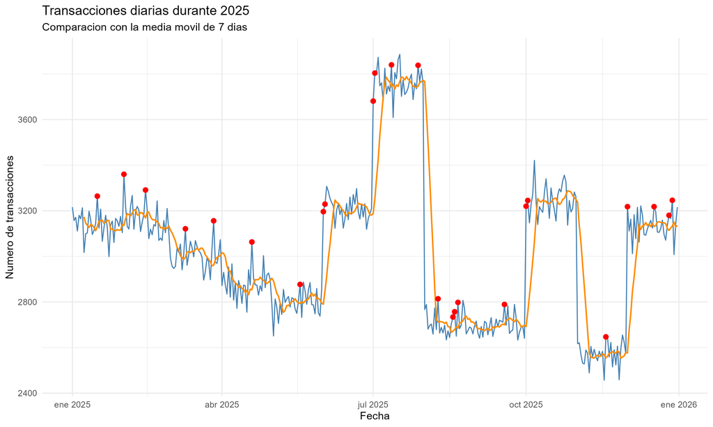

Transacciones diarias, media móvil y días con alerta

## Ejercicio 2 — Ley de Benford

Se analizaron los primeros dígitos de los montos de las transacciones realizadas mediante el canal SINPE Móvil.

La distribución observada se comparó con las probabilidades teóricas de la Ley de Benford.

El MAD general obtenido fue de **0,0032**. El cantón con mayor desviación fue **Garabito**, mientras que únicamente un cantón presentó un MAD superior a 0,015.

### Distribución observada frente a la Ley de Benford

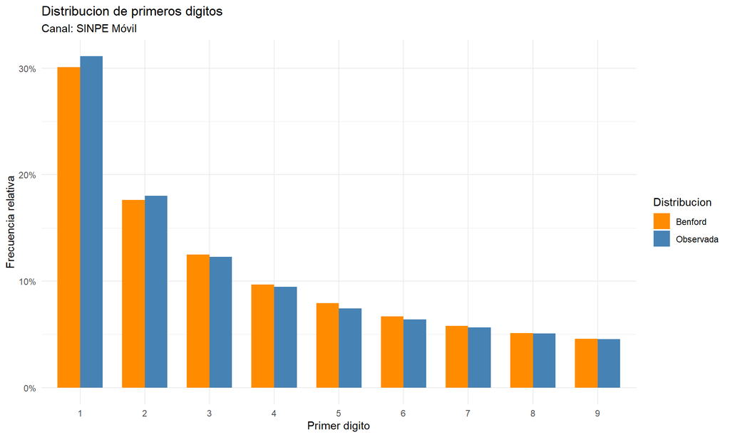

Garabito presenta el mayor MAD (0,0179), pero cuenta con solo 690 transacciones. Esta desviación podría estar relacionada con el tamaño de la muestra y no demuestra fraude por sí sola.

## Ejercicio 3 — Valor acumulado e intereses

Se analizaron los montos mensuales de las transacciones realizadas mediante el canal App, utilizando una tasa efectiva anual del 9 %.

El valor acumulado al 31 de diciembre de 2025 fue de **₡21.765.923.831,82**, de los cuales **₡853.206.531,82** corresponden a intereses ganados.

### Comparación de montos mensuales y valores acumulados

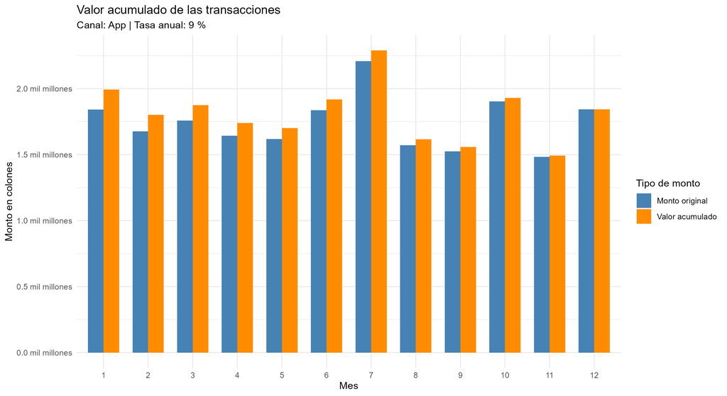

Montos originales y valores acumulados por mes

# Link del git hub

Tambien en los comentarios de la entrega

https://github.com/GuevaraGabriel/Tarea3_GuevaraGabriel?utm_source=chatgpt.com